# Stablecoins: comparazione di USDC, USDT e DAI

Samuele Antonello 162640

Vogliamo confrontare tre importanti stablecoin di Ethereum:

- USDC (indirizzo dello smart contract: 0xa0b86991c6218b36c1d19d4a2e9eb0ce3606eb48)
- USDT (indirizzo dello smart contract: 0xdac17f958d2ee523a2206206994597c13d831ec7)
- DAI (indirizzo dello smart contract: 0x6b175474e89094c44da98b954eedeac495271d0f)

Rispondiamo a due domande:

1. Come differiscono le dimensioni dei loro transfer?
2. Quanto volume di transfer genera ciascuna stablecoin?

Il nostro flusso di lavoro è:

```
Ethereum
   ↓
Etherscan
   ↓
eventi di transfer ERC-20
   ↓
R / tidyverse
   ↓
dimensioni + volumi dei transfer
```

Usiamo Etherscan per recuperare gli eventi di transfer ERC-20 già indicizzati. L’endpoint `tokentx` può essere filtrato direttamente per contratto del token, quindi non serve scaricare prima transfer di altri token.

Usiamo il termine *transfer* e non *transazione*: una transazione Ethereum può generare più eventi di transfer ERC-20.

# Preparazione

Carichiamo i pacchetti e leggiamo la chiave API dal file nascosto `.Renviron` (la chiave non va mai scritta in questo documento).

```r
library(tidyverse)
library(httr2)
library(scales)

api_key = Sys.getenv("ETHERSCAN_API_KEY")
dir.create("data", showWarnings = FALSE)

# formato per scrivere importi in dollari: es. $1.2M
usd = label_dollar(scale_cut = cut_short_scale())
```

I tre contratti sono in una piccola tabella, così ogni passaggio vale per tutte le monete.

```r
stablecoins = tribble(
  ~stablecoin, ~contratto,
  "USDC", "0xa0b86991c6218b36c1d19d4a2e9eb0ce3606eb48",
  "USDT", "0xdac17f958d2ee523a2206206994597c13d831ec7",
  "DAI",  "0x6b175474e89094c44da98b954eedeac495271d0f"
)
```

# Download dei dati

## Scelta del campione

Etherscan restituisce al massimo 10.000 record per richiesta, e le tre monete hanno livelli di attività molto diversi. Se scaricassimo “gli ultimi 10.000 transfer” di ciascuna, coprirebbero periodi di tempo diversi e il confronto dei volumi non avrebbe senso.

Scegliamo quindi **una finestra di blocchi comune** e scarichiamo **tutti** i transfer delle tre monete in quella finestra. Un blocco Ethereum arriva ogni 12 secondi circa, quindi 1000 blocchi sono circa 3 ore. La finestra termina 100 blocchi prima dell’ultimo blocco, per stare lontani da eventuali riorganizzazioni recenti della blockchain.

```r
risposta = request("https://api.etherscan.io/v2/api") |>
  req_url_query(
    chainid = 1,
    module = "proxy",
    action = "eth_blockNumber",
    apikey = api_key
  ) |>
  req_perform() |>
  resp_body_json(simplifyVector = TRUE)

# il risultato è un numero esadecimale (es. "0x1a2b3c"): lo convertiamo
ultimo_blocco <- strtoi(substring(risposta$result, 3), base = 16L)

#organizziamo la finestra in modo che sia lunga ll'incirca 3 ore in modo da limitare il numero di richieste a Etherscan, il blocco finale è 100 blocchi prima dell'ultimo, per evitare blocchi recenti che potrebbero essere riorganizzati nella rete.
finestra = tibble(
  blocco_iniziale = ultimo_blocco - 1100L, #1000 blocchi x 12 sec = circa 3.3 ore
  blocco_finale   = ultimo_blocco - 100L #blocchi recenti esclusi
)

write_csv(finestra, "data/finestra.csv")
```

```r
finestra = read_csv("data/finestra.csv")
finestra
```

```
## # A tibble: 1 × 2
##   blocco_iniziale blocco_finale
##             <dbl>         <dbl>
## 1        26333517      26334517
```

## Funzione di download

Per scaricare i transfer di un token non passiamo un `address`, ma un `contractaddress`: Etherscan restituisce allora tutti i transfer di quel token.

La funzione divide la finestra in pezzi da 100 blocchi, ne scarica uno alla volta e unisce i risultati.Controlliamo `is.character(risposta$result)`: quando non ci sono dati (o c’è un errore) Etherscan restituisce un messaggio di testo invece di una tabella. Se un pezzo arriva a 10.000 righe, potrebbe essere stato troncato e la funzione ci avvisa.

```r
scarica_transfer = function(contratto, blocco_iniziale, blocco_finale,
                             passo = 100) {

  inizi = seq(blocco_iniziale, blocco_finale, by = passo)

  pezzi = map(inizi, \(inizio) {
    message("Blocchi da ", inizio)
    Sys.sleep(0.4)   # il piano gratuito limita le richieste al secondo

    risposta = request("https://api.etherscan.io/v2/api") |>
      req_url_query(
        chainid = 1,
        module = "account",
        action = "tokentx",
        contractaddress = contratto,
        startblock = as.integer(inizio),
        endblock = as.integer(min(inizio + passo - 1, blocco_finale)),
        page = 1,
        offset = 10000,
        sort = "asc",
        apikey = api_key
      ) |>
      req_perform() |>
      resp_body_json(simplifyVector = TRUE)

    if (is.character(risposta$result)) {
      if (grepl("No transactions", risposta$result)) return(tibble())
      stop("Errore di Etherscan: ", risposta$result)
    }

    if (nrow(risposta$result) == 10000) {
      warning("Pezzo di ", passo, " blocchi troncato: riduci 'passo'.")
    }

    as_tibble(risposta$result)
  })

  bind_rows(pezzi)
}
```

Scarichiamo le tre monete (da eseguire una sola volta: i dati grezzi vengono salvati in `data/`).

```r
for (i in 1:nrow(stablecoins)) {
  dati <- scarica_transfer(
    stablecoins$contratto[i],
    finestra$blocco_iniziale,
    finestra$blocco_finale
  )
  write_csv(dati, paste0("data/", stablecoins$stablecoin[i], ".csv"))
}
```

## Pulizia

Etherscan restituisce tutto come testo. Il passaggio fondamentale riguarda l’importo: i valori ERC-20 sono interi espressi nell’unità più piccola del token, e ogni token dichiara quanti decimali usa (`tokenDecimal`):

$$\text{importo in dollari} =
\frac{\text{value}}{10^{\text{tokenDecimal}}}$$

USDC e USDT hanno 6 decimali, DAI ne ha 18. Dimenticare questo passaggio renderebbe gli importi di DAI $10^{12}$ volte più grandi degli altri due coin.

```r
transfers <- stablecoins$stablecoin |>
  map(\(moneta) {
    read_csv(paste0("data/", moneta, ".csv"),
             col_types = cols(.default = col_character())) |>
      mutate(stablecoin = moneta)
  }) |>
  bind_rows() |>
  transmute(
    stablecoin = factor(stablecoin, levels = c("USDC", "USDT", "DAI")),
    blocco = as.numeric(blockNumber),
    tempo = as.POSIXct(as.numeric(timeStamp), origin = "1970-01-01", tz = "UTC"),
    hash,
    from,
    to,
    importo = as.numeric(value) / 10^as.numeric(tokenDecimal)
  )

glimpse(transfers)
```

```
## Rows: 22,501
## Columns: 7
## $ stablecoin <fct> USDC, USDC, USDC, USDC, USDC, USDC, USDC, USDC, USDC, USDC,…
## $ blocco     <dbl> 26333517, 26333517, 26333517, 26333517, 26333517, 26333517,…
## $ tempo      <dttm> 2026-11-03 09:56:35, 2026-11-03 09:56:35, 2026-11-03 09:56…
## $ hash       <chr> "0xebd1e215ca939a987ce1332f7f9cfc15e9ced5a09504911a68876bf9…
## $ from       <chr> "0x000000000004444c5dc75cb358380d2e3de08a90", "0xdb1475c245…
## $ to         <chr> "0x0000000aa232009084bd71a5797d089aa4edfad4", "0x63e2b1060b…
## $ importo    <dbl> 9.603902e+02, 5.000000e-04, 5.000000e-04, 1.020000e+01, 3.2…
```

Un rapido controllo: le tre monete devono coprire la stessa finestra, e vediamo quanti transfer hanno importo zero (sono validi, ma non si possono rappresentare su scala logaritmica).

```r
transfers |>
  group_by(stablecoin) |>
  summarise(
    transfer = n(),
    primo_blocco = min(blocco),
    ultimo_blocco = max(blocco),
    importo_zero = sum(importo == 0)
  )
```

```
## # A tibble: 3 × 5
##   stablecoin transfer primo_blocco ultimo_blocco importo_zero
##   <fct>         <int>        <dbl>         <dbl>        <int>
## 1 USDC          10131     26333517      26334517          674
## 2 USDT          10153     26333517      26334517          712
## 3 DAI            2217     26333517      26334517           63
```

# Punto 1:

*Come differiscono le dimensioni dei transfer?* Vediamo alcune statistiche descrittive:

```r
sintesi = transfers |>
  filter(importo > 0) |>
  group_by(stablecoin) |>
  summarise(
    n = n(),
    media = mean(importo),
    mediana = median(importo),
    massimo = max(importo)
  )

sintesi |>
  mutate(across(media:massimo, \(x) round(x, 2)))
```

```
## # A tibble: 3 × 5
##   stablecoin     n   media mediana    massimo
##   <fct>      <int>   <dbl>   <dbl>      <dbl>
## 1 USDC        9457 116222.    200. 100200000
## 2 USDT        9441  34327.    118.  31055972.
## 3 DAI         2154 140865.    922.  20057949.
```

Per tutte le monete la media è molto più alta della mediana: pochi transfer enormi spingono in alto la media.

Osserviamo la distribuzione delle dimensioni relativa a ogni coin, le dimensioni coprono molti ordini di grandezza, quindi usiamo la scala logaritmica.

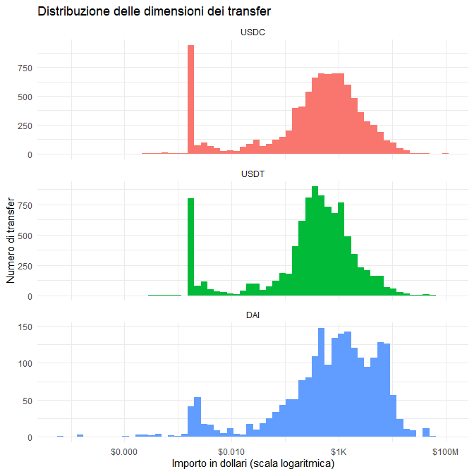

```r
transfers |>
  filter(importo > 0) |>
  ggplot(aes(importo, fill = stablecoin)) +
  geom_histogram(bins = 60, show.legend = FALSE) +
  scale_x_log10(labels = usd) +
  facet_wrap(~ stablecoin, ncol = 1, scales = "free_y") +
  labs(
    title = "Distribuzione delle dimensioni dei transfer",
    x = "Importo in dollari (scala logaritmica)",
    y = "Numero di transfer"
  ) +
  theme_minimal()
```

Osservare le Classi di importo può essere interessante, dunque raggruppiamo i transfer in classi di importo e confrontiamo la composizione di ciascuna moneta:

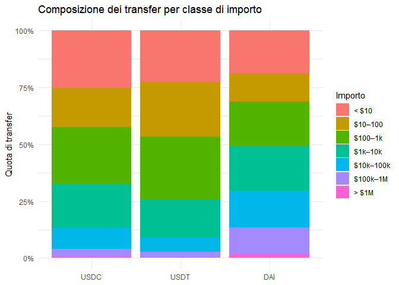

```r
transfers <- transfers |>
  mutate(
    classe = cut(
      importo,
      breaks = c(-Inf, 0, 10, 100, 1e3, 1e4, 1e5, 1e6, Inf),
      labels = c("zero", "< $10", "$10–100", "$100–1k", "$1k–10k",
                 "$10k–100k", "$100k–1M", "> $1M"),
      right = FALSE
    )
  )

transfers |>
  filter(importo > 0) |>
  ggplot(aes(stablecoin, fill = classe)) +
  geom_bar(position = "fill") +
  scale_y_continuous(labels = label_percent()) +
  labs(
    title = "Composizione dei transfer per classe di importo",
    x = NULL,
    y = "Quota di transfer",
    fill = "Importo"
  ) +
  theme_minimal()
```

```r
transfers |>
  filter(importo > 0) |>
  group_by(stablecoin) |>
  arrange(desc(importo), .by_group = TRUE) |>
  summarise(quota_top1 = sum(importo[1:ceiling(0.01 * n())]) / sum(importo)) |>
  mutate(quota_top1 = label_percent(accuracy = 0.1)(quota_top1))
```

```
## # A tibble: 3 × 2
##   stablecoin quota_top1
##   <fct>      <chr>
## 1 USDC       90.5%
## 2 USDT       83.7%
## 3 DAI        67.1%
```

Notiamo che nel nostro campione l’1% dei transfer USDC più grandi (per esempio) muove il 90.5% dell’importo totale trasferito in USDC, il restante 99% dei transfer di divide il restante 9.5% del valore, dunque l’importo trasferito (specialmente in USDC ma in maniera simile negli altri due coin) è estremamente concentrato in pochi transfer, questo è coerente con la forte asimmetria osservata nelle distribuzioni (media molto superiore alla mediana).

# Punto 2:

*Quanto volume genera ciascuna stablecoin?*

Per *volume* intendiamo la somma degli importi di tutti i transfer nella finestra, in dollari (ogni stablecoin vale circa un dollaro).

Vediamo il volume totale:

Distinguiamo transfer (righe), transazioni (hash distinti: una transazione può contenere più transfer) e indirizzi attivi.

```r
volumi <- transfers |>
  group_by(stablecoin) |>
  summarise(
    volume = sum(importo),
    n_transfer = n(),
    n_transazioni = n_distinct(hash),
    mittenti = n_distinct(from),
    destinatari = n_distinct(to)
  )

volumi |>
  mutate(volume = usd(volume))
```

```
## # A tibble: 3 × 6
##   stablecoin volume n_transfer n_transazioni mittenti destinatari
##   <fct>      <chr>       <int>         <int>    <int>       <int>
## 1 USDC       $1B         10131          5812     4485        5031
## 2 USDT       $324M       10153          6942     4956        5976
## 3 DAI        $303M        2217          1151      442         511
```

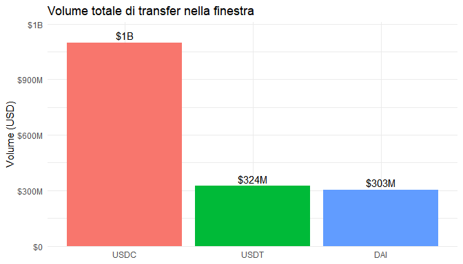

```r
ggplot(volumi, aes(stablecoin, volume, fill = stablecoin)) +
  geom_col(show.legend = FALSE) +
  geom_text(aes(label = usd(volume)), vjust = -0.4) +
  scale_y_continuous(labels = usd, expand = expansion(mult = c(0, 0.1))) +
  labs(
    title = "Volume totale di transfer nella finestra",
    x = NULL,
    y = "Volume (USD)"
  ) +
  theme_minimal()
```

E’ evidente che USDC muove molto più denaro degli altri due coin.

Bisogna però considerare il numero di transfer in relazione volume.

Una moneta può avere molto volume perché ha **molti** transfer, o perché i suoi transfer sono **grandi** (o entrambe le cose). Confrontare la quota sul totale dei transfer con la quota sul volume separa i due effetti.

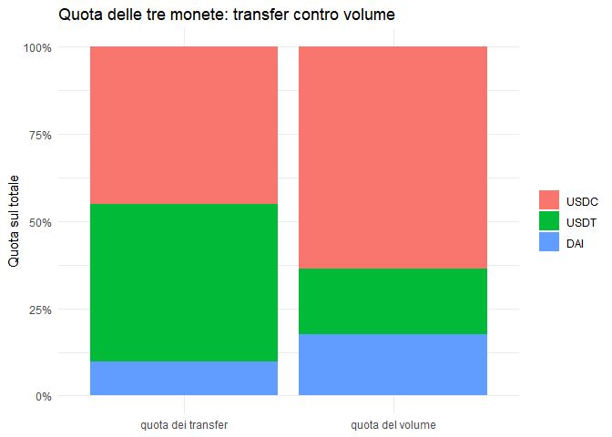

```r
volumi |>
  transmute(
    stablecoin,
    `quota dei transfer` = n_transfer / sum(n_transfer),
    `quota del volume` = volume / sum(volume)
  ) |>
  pivot_longer(-stablecoin, names_to = "misura", values_to = "quota") |>
  ggplot(aes(misura, quota, fill = stablecoin)) +
  geom_col() +
  scale_y_continuous(labels = label_percent()) +
  labs(
    title = "Quota delle tre monete: transfer contro volume",
    x = NULL,
    y = "Quota sul totale",
    fill = NULL
  ) +
  theme_minimal()
```

Questo grafico confronta la quota di ciascun coun sul numero di transfer con la sua quota sul volume, notiamo che USDC e USDT hanno un numero di transfer simile ma i volumi sono molto diversi, ne consegue che in media i transfer USDC sono molto più grandi di quelli USDT, che sono numerosi ma di importo ridotto. DAI ha pochi transfer ma una quota di volume quasi doppia, segno di importi medi relativamente elevati.

Ha senso dunque domandarsi da quali transfer arriva il volume?

Il volume è una *somma*, e le somme di variabili con code pesanti sono dominate dai valori più grandi. Vediamo quali classi di importo generano il volume e confrontiamo con il grafico per numero di transfer della Domanda 1.

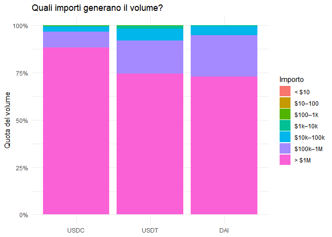

```r
transfers |>
  filter(importo > 0) |>
  group_by(stablecoin, classe) |>
  summarise(volume = sum(importo), .groups = "drop") |>
  ggplot(aes(stablecoin, volume, fill = classe)) +
  geom_col(position = "fill") +
  scale_y_continuous(labels = label_percent()) +
  labs(
    title = "Quali importi generano il volume?",
    x = NULL,
    y = "Quota del volume",
    fill = "Importo"
  ) +
  theme_minimal()
```

# Conclusioni

**Dimensioni.** Nel nostro campione DAI ha il transfer tipico (mediano) più grande, circa $922, mentre USDT ha il più piccolo, circa $118. Per tutte le monete la distribuzione è fortemente asimmetrica a destra: la media è molto sopra la mediana e una piccola frazione di transfer muove gran parte del denaro.

**Volume.** USDC genera il volume maggiore nella finestra ($1B), mentre USDT ha più transfer (10,153). USDT ha tanti transfer piccoli, che fanno pensare a un uso più da “bot”, USDC e DAI hanno meno transfer ma più grandi, che fanno pensare a movimenti tra grandi operatori o protocolli.

E’ necessario considerare che la finestra di analisi di questi coin è limitata, infatti il campione copre solo circa 3 ore di attività: volumi e dimensioni cambiano nell’arco della giornata, della settimana e con gli eventi di mercato, quindi i risultati non sono medie di lungo periodo.